# Preprocessing

Guided practice

In this guided practice we will address how to preprocess data for a machine learning modeling in `tidymodels`. We will work with the **Home Mortgage Disclosure Act Data, NY, 2015** provided and compiled by the [Consumer Finance Protection Board](https://www.kaggle.com/datasets/jboysen/ny-home-mortgage?resource=download). This dataset covers all mortgage decisions made in 2015 for the state of New York.

```r
head(data)
```

| respondent_id | action_taken_name | agency_name | applicant_ethnicity_name | applicant_race_name_1 | applicant_sex_name | co_applicant_ethnicity_name | co_applicant_race_name_1 | co_applicant_sex_name | county_name | lien_status_name | loan_purpose_name | loan_type_name | msamd_name | owner_occupancy_name | preapproval_name | property_type_name | purchaser_type_name | hud_median_family_income | loan_amount_000s | number_of_1_to_4_family_units | number_of_owner_occupied_units | minority_population | population | tract_to_msamd_income |
| --- | --- | --- | --- | --- | --- | --- | --- | --- | --- | --- | --- | --- | --- | --- | --- | --- | --- | --- | --- | --- | --- | --- | --- | --- |
| 0000476810 | Application withdrawn by applicant | Consumer Financial Protection Bureau | Not Hispanic or Latino | White | Male | Not Hispanic or Latino | White | Female | Westchester County | Secured by a first lien | Refinancing | Conventional | New York, Jersey City, White Plains - NY, NJ | Owner-occupied as a principal dwelling | Not applicable | One-to-four family dwelling (other than manufactured housing) | Loan was not originated or was not sold in calendar year covered by register | 71300 | 300 | 2044 | 1904 | 11.69 | 6358 | 307.65 |
| 0002888798 | Loan originated | Federal Reserve System | Not Hispanic or Latino | White | Male | Not Hispanic or Latino | White | Female | Suffolk County | Secured by a first lien | Refinancing | Conventional | Nassau County, Suffolk County - NY | Owner-occupied as a principal dwelling | Not applicable | One-to-four family dwelling (other than manufactured housing) | Fannie Mae (FNMA) | 109000 | 253 | 1383 | 1344 | 12.71 | 4562 | 130.66 |
| 02-0594137 | Application withdrawn by applicant | Department of Housing and Urban Development | Not Hispanic or Latino | White | Female | Not Hispanic or Latino | White | Female | Rockland County | Secured by a first lien | Refinancing | Conventional | New York, Jersey City, White Plains - NY, NJ | Owner-occupied as a principal dwelling | Not applicable | One-to-four family dwelling (other than manufactured housing) | Loan was not originated or was not sold in calendar year covered by register | 71300 | 240 | 2248 | 2046 | 14.28 | 8006 | 206.39 |
| 22-3039688 | Loan originated | Department of Housing and Urban Development | Not Hispanic or Latino | White | Male | No co-applicant | No co-applicant | No co-applicant | Queens County | Secured by a first lien | Home purchase | Conventional | New York, Jersey City, White Plains - NY, NJ | Owner-occupied as a principal dwelling | Not applicable | One-to-four family dwelling (other than manufactured housing) | Other type of purchaser | 71300 | 115 | 2348 | 1740 | 60.80 | 6401 | 116.88 |
| 0000451965 | Application denied by financial institution | Consumer Financial Protection Bureau | Not Hispanic or Latino | White | Male | Not Hispanic or Latino | White | Female | Nassau County | Secured by a first lien | Refinancing | Conventional | Nassau County, Suffolk County - NY | Owner-occupied as a principal dwelling | Not applicable | One-to-four family dwelling (other than manufactured housing) | Loan was not originated or was not sold in calendar year covered by register | 109000 | 286 | 2147 | 1944 | 28.39 | 6762 | 158.82 |
| 22-3039688 | Loan originated | Department of Housing and Urban Development | Not Hispanic or Latino | White | Female | No co-applicant | No co-applicant | No co-applicant | Nassau County | Secured by a first lien | Home purchase | FHA-insured | Nassau County, Suffolk County - NY | Owner-occupied as a principal dwelling | Not applicable | One-to-four family dwelling (other than manufactured housing) | Ginnie Mae (GNMA) | 109000 | 343 | 1564 | 1517 | 15.94 | 5032 | 124.04 |

As you can see, this dataset contains various information regarding the people who applied for loans and the neighborhoods in which they live: demographic and socio-economical. We have some categorical variables, such as: respondent_id, action_taken_name, agency_name, applicant_ethnicity_name, applicant_race_name_1, applicant_sex_name, co_applicant_ethnicity_name, co_applicant_race_name_1, co_applicant_sex_name, county_name, lien_status_name, loan_purpose_name, loan_type_name, msamd_name, owner_occupancy_name, preapproval_name, property_type_name, purchaser_type_name. But also numerical features: hud_median_family_income, loan_amount_000s, number_of_1_to_4_family_units, number_of_owner_occupied_units, minority_population, population, tract_to_msamd_income.

The first way in which we can get an overview of our data is using the `summary()` function.

```r
summary(data)
```

```
##  respondent_id      action_taken_name  agency_name
##  Length:50000       Length:50000       Length:50000
##  Class :character   Class :character   Class :character
##  Mode  :character   Mode  :character   Mode  :character
##
##
##
##
##  applicant_ethnicity_name applicant_race_name_1 applicant_sex_name
##  Length:50000             Length:50000          Length:50000
##  Class :character         Class :character      Class :character
##  Mode  :character         Mode  :character      Mode  :character
##
##
##
##
##  co_applicant_ethnicity_name co_applicant_race_name_1 co_applicant_sex_name
##  Length:50000                Length:50000             Length:50000
##  Class :character            Class :character         Class :character
##  Mode  :character            Mode  :character         Mode  :character
##
##
##
##
##  county_name        lien_status_name   loan_purpose_name  loan_type_name
##  Length:50000       Length:50000       Length:50000       Length:50000
##  Class :character   Class :character   Class :character   Class :character
##  Mode  :character   Mode  :character   Mode  :character   Mode  :character
##
##
##
##
##   msamd_name        owner_occupancy_name preapproval_name   property_type_name
##  Length:50000       Length:50000         Length:50000       Length:50000
##  Class :character   Class :character     Class :character   Class :character
##  Mode  :character   Mode  :character     Mode  :character   Mode  :character
##
##
##
##
```

[output cut: 9 more lines]

```
##  Min.   :   6                  Min.   :   4
##  1st Qu.: 965                  1st Qu.: 741
##  Median :1520                  Median :1196
##  Mean   :1513                  Mean   :1215
##  3rd Qu.:2011                  3rd Qu.:1646
##  Max.   :6345                  Max.   :6454
##  NA's   :251                   NA's   :229
##  minority_population   population    tract_to_msamd_income
##  Min.   :  0.34      Min.   :    1   Min.   : 15.44
##  1st Qu.:  7.81      1st Qu.: 3456   1st Qu.: 88.29
##  Median : 17.22      Median : 4568   Median :106.91
##  Mean   : 29.40      Mean   : 4760   Mean   :117.94
##  3rd Qu.: 39.72      3rd Qu.: 5907   3rd Qu.:131.62
##  Max.   :100.00      Max.   :26588   Max.   :367.61
##  NA's   :183         NA's   :183     NA's   :197
```

This returns a large chunk with an overview of the minimum, maximum, interquartile values and number of NA’s for each of the rows. This might be a lot of information at first, but we can see an overview of the summary values of the datset. In general, we can distinguish:

- missing values in the columns of family units, occupied units, family income, population values and MSAMD income.
- outliers in the columns of loan ammounts, number of fmaily units, population, MSAMD income and family income. The categorical values are not interpretable, since they appear as character values and we are not able to see a count of the categories. The first step we should do here is **transform** the type of variable from character to factor. Factor variables are used to work with categorical variables that have a fixed and known set of possible values. So we will make a transformation on all our character variables to factor.

```r
data <- data %>% mutate_if(is.character, ~as.factor(.))
```

Now, let’s look at the summary of those variables.

```r
summary(data %>% select(action_taken_name:purchaser_type_name))
```

```
##                                    action_taken_name
##  Application approved but not accepted      : 1674
##  Application denied by financial institution: 8908
##  Application withdrawn by applicant         : 4473
##  File closed for incompleteness             : 1895
##  Loan originated                            :26142
##  Loan purchased by the institution          : 6908
##
##                                       agency_name
##  Consumer Financial Protection Bureau       :20157
##  Department of Housing and Urban Development:17258
##  Federal Deposit Insurance Corporation      : 1711
##  Federal Reserve System                     : 1149
##  National Credit Union Administration       : 5827
##  Office of the Comptroller of the Currency  : 3898
##
##                                                                       applicant_ethnicity_name
##  Hispanic or Latino                                                               : 2849
##  Information not provided by applicant in mail, Internet, or telephone application: 5027
##  Not applicable                                                                   : 5753
##  Not Hispanic or Latino                                                           :36371
##
##
##
##                                                                        applicant_race_name_1
##  American Indian or Alaska Native                                                 :  200
##  Asian                                                                            : 3165
##  Black or African American                                                        : 3246
##  Information not provided by applicant in mail, Internet, or telephone application: 5384
##  Native Hawaiian or Other Pacific Islander                                        :  152
##  Not applicable                                                                   : 5720
##  White                                                                            :32133
##                                                                          applicant_sex_name
##  Female                                                                           :13644
##  Information not provided by applicant in mail, Internet, or telephone application: 3091
##  Male                                                                             :27545
##  Not applicable                                                                   : 5720
##
##
##
```

[output cut: 65 more lines]

```
##  Manufactured housing                                         :  761
##  Multifamily dwelling                                         :  631
##  One-to-four family dwelling (other than manufactured housing):48608
##
##
##
##
##                                                                    purchaser_type_name
##  Loan was not originated or was not sold in calendar year covered by register:28905
##  Fannie Mae (FNMA)                                                           : 5848
##  Ginnie Mae (GNMA)                                                           : 4633
##  Freddie Mac (FHLMC)                                                         : 4134
##  Commercial bank, savings bank or savings association                        : 2259
##  Life insurance company, credit union, mortgage bank, or finance company     : 1739
##  (Other)                                                                     : 2482
```

Now, we can see the count of categories for each variable and the appearance of NA’s. The variables that contain NA are county_name and msamd_name. The function `summary` also sums up categories with a relative low frequency into the group `(Other)`, as in the case of purchaser_type_name.

We could explore this by each variable:

```r
summary(data$hud_median_family_income)
```

```
##    Min. 1st Qu.  Median    Mean 3rd Qu.    Max.    NA's
##   57200   69700   71300   78259   82700  109000     180
```

## Missing values

An useful package to analyze presence of missing values within a dataset is `Amelia`. The function `missmap` allows us to get an overview of the missing values within a dataset for each column and observation.

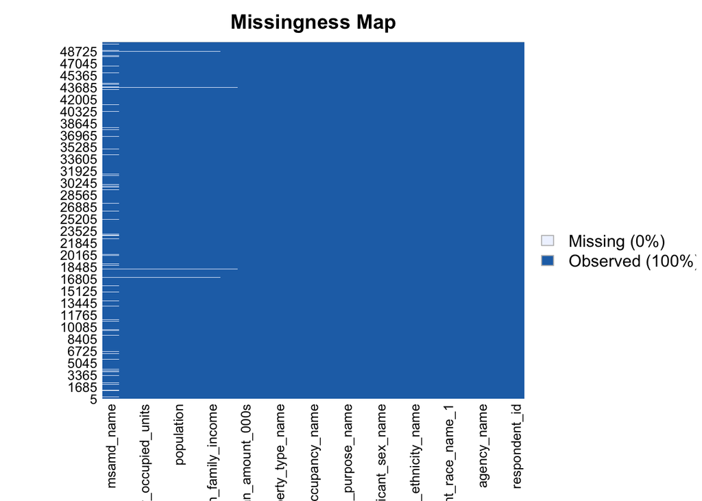

```r
missmap(data)
```

In the theory, we addressed that NA’s could be handled by being deleted or imputated. Deletion of NA’s is the easiest solution, since we have different ways to address it. Tidyverse contains the function `drop_na()`, that removes rows where any column specified contains a missing value. If we don’t specify anything, it removes rows that contain a missing value across *any* column.

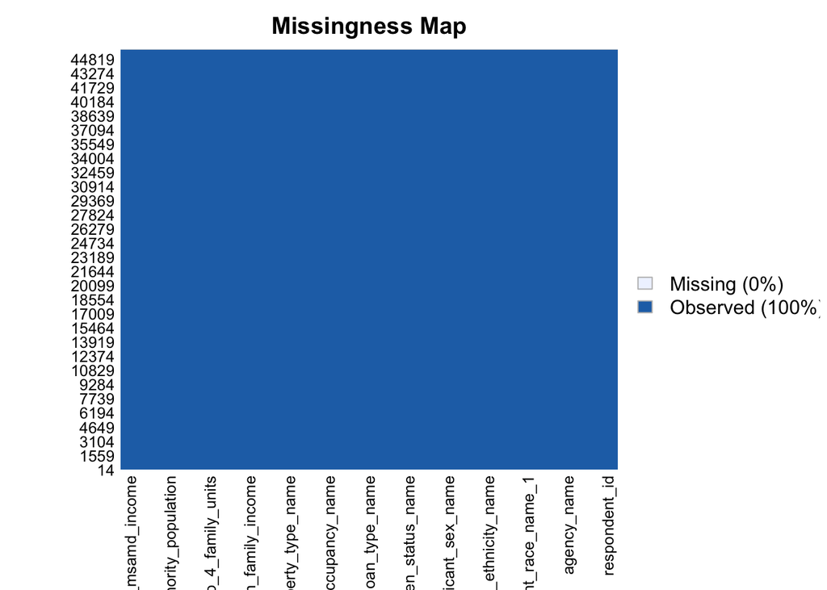

```r
removing_all_na <- data %>% drop_na()

missmap(removing_all_na)
```

To specify a column, we just have to write it down between the parenthesis.

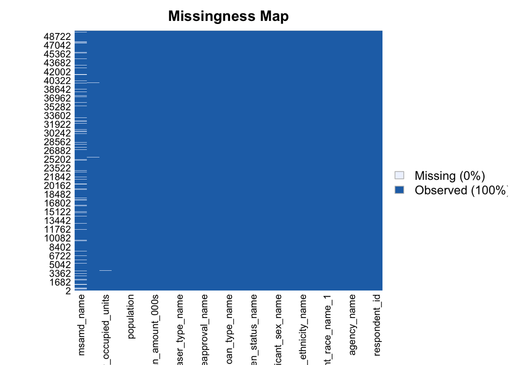

```r
removing_na_population <- data %>% drop_na(population)

missmap(removing_na_population)
```

We can select multiple columns separating them by commas.

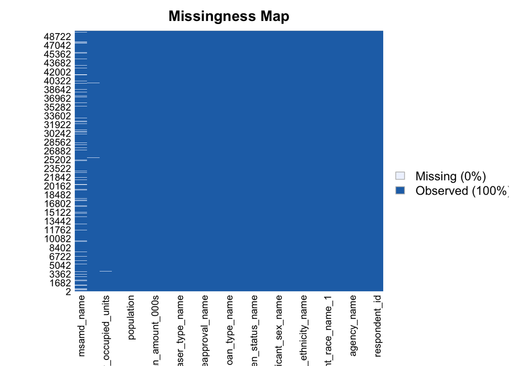

```r
removing_na_pop_minority <- data %>% drop_na(minority_population, population)

missmap(removing_na_pop_minority)
```

Other times, we might be interested in removing variables where most of the rows have NA. If the sample is not big enough, it won’t make sense to imputate values.

```r
data %>%
  summarise(across(everything(), ~ sum(is.na(.)))) %>%
  unlist %>%
  sort(decreasing = T)
```

```
##                     msamd_name  number_of_1_to_4_family_units
##                           4058                            251
## number_of_owner_occupied_units          tract_to_msamd_income
##                            229                            197
##            minority_population                     population
##                            183                            183
##       hud_median_family_income                    county_name
##                            180                            131
##                  respondent_id              action_taken_name
##                              0                              0
##                    agency_name       applicant_ethnicity_name
##                              0                              0
##          applicant_race_name_1             applicant_sex_name
##                              0                              0
##    co_applicant_ethnicity_name       co_applicant_race_name_1
##                              0                              0
##          co_applicant_sex_name               lien_status_name
##                              0                              0
##              loan_purpose_name                 loan_type_name
##                              0                              0
##           owner_occupancy_name               preapproval_name
##                              0                              0
##             property_type_name            purchaser_type_name
##                              0                              0
##               loan_amount_000s
##                              0
```

# Imputation of values

Now, recall that removing rows that contain missing values in the dataframe carries the problem to remove potential information from other features that could be relevant to our model. This is why we can also use imputation of values for the variables to replace the missing value with an existing one, and keep the row as information for the model. The package `Amelia` contains functions to perform multiple imputation regression on the dataset. This is beyond the scope of this class, we will address manual imputations with tidyverse, but the documentation to explore that kind of imputation [is available](https://cran.r-project.org/web/packages/Amelia/vignettes/using-amelia.html).

We will address how to perform imputation of variables with `tidyverse`. We will use as an example the variable `hud_median_family_income`, which we saw contains 180 missing values. The distribution of this variable looks the following way:

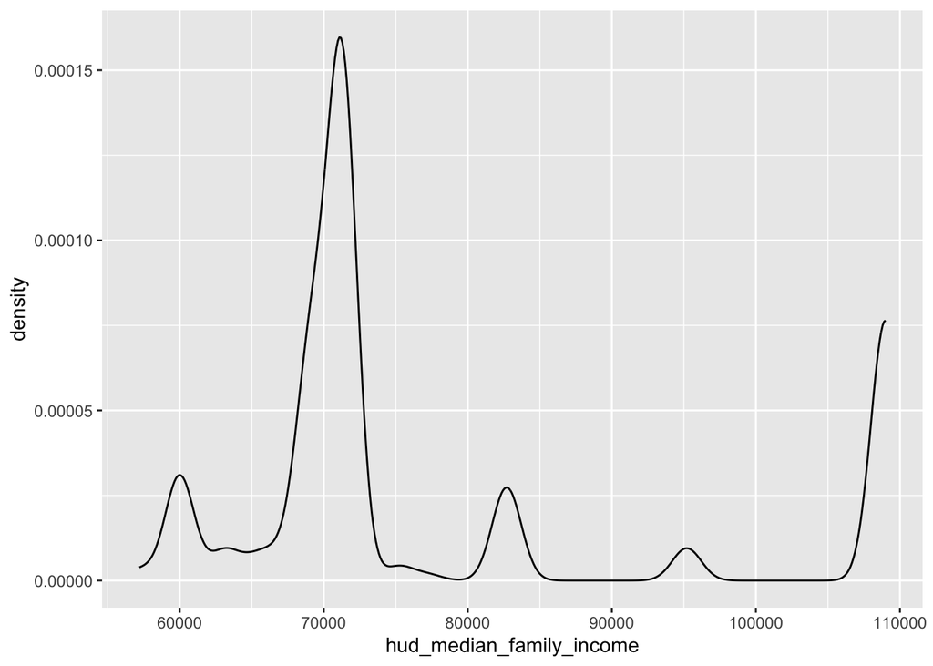

```r
ggplot(data, aes(x = hud_median_family_income))+
  geom_density()
```

The distribution of values shows sparsity with no discernible central tendency or normal distribution. A noteworthy observation is the concentration around an income level of $70,000 USD. In the context of imputation, the objective is to substitute missing values with those making the minimal influence on the variable’s distribution. This is why we can employ the median. We can use the `mutate` and `if_else` functions from the `tidyverse` to replace NA values with the column’s median value.

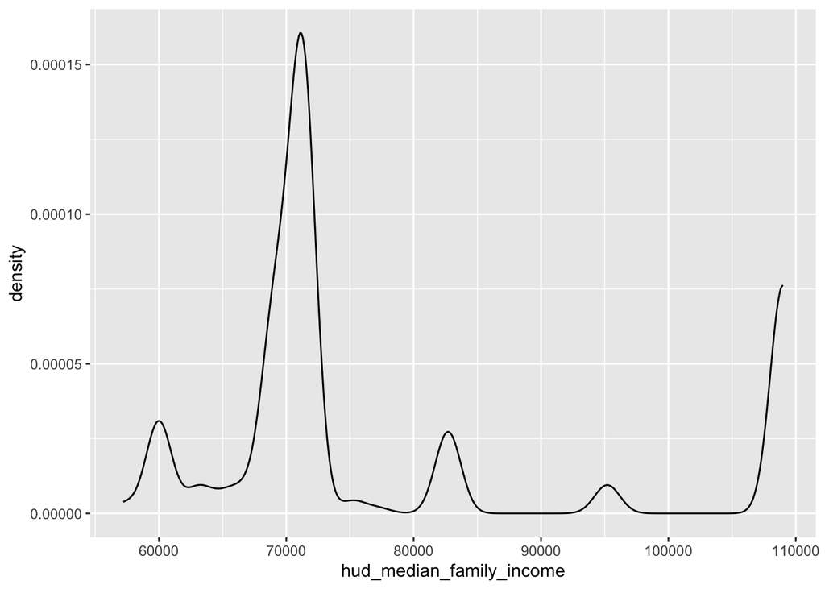

```r
replace_na_mean_income <- data %>%
  mutate(hud_median_family_income = if_else(
  is.na(hud_median_family_income),
  median(hud_median_family_income, na.rm = T),
  hud_median_family_income))

ggplot(replace_na_mean_income, aes(x = hud_median_family_income))+
  geom_density()
```

We can see that this returns the same distribution for the variable that we had before! Note that this is the case when we have a low number of missing values and a large data set. In data sets with many missing values, this might introduce more bias, but in this case it seems like a good solution. We can impute the median to all numerical values:

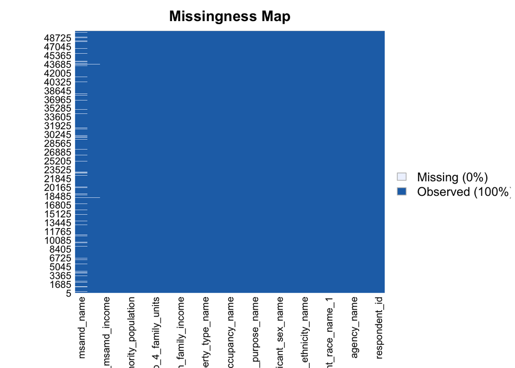

```r
data <- data %>% mutate_if(is.numeric, ~if_else(is.na(.), median(., na.rm = T), .))

missmap(data)
```

Now, we have the remaining problem of the NA’s in categorical values. Following the same logic we had for numerical values, we can impute the mode for the variables with NA in factor columns using the function `mlv` from the package `modeest`.

```r
data <- data %>%
  mutate_if(is.factor, ~if_else(is.na(.), modeest::mlv(.), .))
```

This has the same result as the imputation with the median. While we introduce bias to the data, the general distribution of the variables is not modified.

## Outliers

One way of detecting outliers is by looking at the maximum and minimum values printed out in the `summary()` descriptive statistics. However, this is not the only way to discover outliers in a dataframe. Drawing a boxplot is also useful to detect these values. Recall that these graphs help visualize a quantitative variable by displaying five common location summary (minimum, median, first and third quartiles and maximum) and any observation that was classified as a suspected outlier. A boxplot identifies these values by defining an upper and lower bound for potential outliers:

- Lower Bound: Q1 (first quartile) - 1.5 * IQR (interquartile range)
- Upper Bound: Q3 (third quartile) + 1.5 * IQR (interquartile range)

Any data point below the lower bound or above the upper bound is considered an outlier. These values are identified as individual points outside the whiskers of the boxplot. For example, look at this boxplot of the median family income:

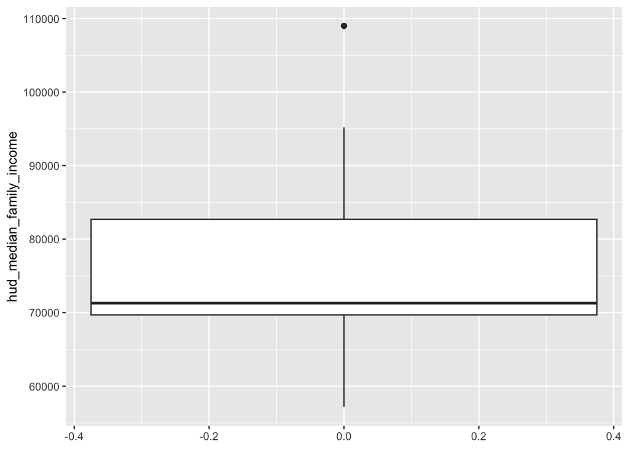

```r
ggplot(data, aes(y = hud_median_family_income))+
  geom_boxplot()
```

There is a clear outlier of a family that has a median income of $110,000 USD. We could replace that value manually, first calculating the lower and upper bound.

```r
Q1 <- quantile(data$hud_median_family_income, na.rm = T)[2]
Q3 <- quantile(data$hud_median_family_income, na.rm = T)[4]

IQR <- IQR(data$hud_median_family_income, na.rm = T)

lower_bound <- Q1 - 1.5*IQR
upper_bound <- Q3 + 1.5*IQR
```

And then replacing the values in the data that match the criteria.

```r
data <- data %>% mutate(hud_median_family_income =
                  if_else(
                   hud_median_family_income < lower_bound | hud_median_family_income > upper_bound,
                   median(hud_median_family_income, na.rm = T),
                   hud_median_family_income
                  ))

summary(data$hud_median_family_income)
```

```
##    Min. 1st Qu.  Median    Mean 3rd Qu.    Max.
##   57200   69700   71300   70990   71300   95200
```

This changes the distribution of the variable completely, so it’s important to remember that these decisions produce an important bias on our dataset.

### Tidymodels

The package to work with machine learning modeling in R is called `tidymodels`. It exists as part of the `tidyverse`, but has to be installed separately. It works with *workflows*, objects that can bundle together pre-processing, modeling, and post-processing requests (Silge and Julia, n.d.).

The concept of workflows introduces a shift in perspective, directing our attention towards a holistic *modeling process* rather than solely fixating on tailoring a specific model for parameter estimation. In essence, this entails viewing modeling not merely as the determination of function parameters and their alignment with our data but as a comprehensive sequence involving preprocessing, parameter estimation, fitting, post-processing, and iterative refinement. The optimal model won’t be achieved in the initial training. In further classes, we will see that achieving an ideal model involves evaluating its performance with diverse parameters and undergoing multiple training iterations. Consequently, binding together the analytical components of data modeling is important for the accurate estimation of the ideal model.

[figure not shown]

We can use `tidymodels` workflows with the function `workflow()`.

In the practical sense, these objects allow us to adjust an realize predictions with a simple `fit()` and `predict()` call, in a single object that already has saved the entire preprocessing. We define the preprocessing of the data with the function `recipe()`. Unlike the formula method inside a modeling function, the recipe defines the steps via `step_*()` functions without immediately executing them; it is only a specification of what should be done. It is important to note that recipes can be used as preprocessing for the modeling, but also for the cleaning and transformation of the data.

A basic recipe that predicts the mortgage status looks the following:

```r
mortgage_rec <- recipe(action_taken_name ~ ., data = data)

mortgage_rec
```

It has two arguments:

- A **formula**. Any variable on the left-hand side of the tilde (`~`) is considered the model outcome (here, `action_taken_name`). On the right-hand side of the tilde are the predictors. Variables may be listed by name, or we can use the dot (`.`) to indicate all other variables as predictors.
- The **data**. A recipe is associated with the data set used to create the model. This will typically be the *training* set, so `data = data` here.

Here, our variables are classified into only two roles (“Manually Alter Roles Roles,” n.d.): predictors and an outcome. However, our data contains the variable `respondent_id`, which is not actually a predictor. Recipes can label and retain column(s) of the data set that should not be treated as outcomes or predictors.

```r
mortgage_rec <- mortgage_rec %>%
  update_role(respondent_id, new_role = "ID")

mortgage_rec
```

Note that we can update the steps of the preprocessing directly on the recipe object using pipes.

We can use tidymodels recipes to perform imputations on NA. For example, we can use the function `step_impute_mode()` to impute the mode on NA’s for categorical variables.

```r
mortgage_rec <- mortgage_rec %>%
  update_role(respondent_id, new_role = "ID") %>%
  step_impute_mode(msamd_name) %>%
  prep()

tidy(mortgage_rec, number = 1)
```

| terms | value | id |
| --- | --- | --- |
| msamd_name | New York, Jersey City, White Plains - NY, NJ | impute_mode_21vk7 |

The function `tidy()` summarizes information about the model’s components. In this case, it shows us the mode which was used to impute values in the variable msamd_name. [Here](https://recipes.tidymodels.org/reference/index.html#step-functions-imputation) is a full list of all the steps available for imputation.

## Dealing with highly correlated variables

Recall that we addressed multicolinearity of variables as an issue because it might overfit the data, or reduce a models’ robustness. To explore multicolinearity, we can use the function `cor()` from R base.

```r
correlation_of_variables <- data %>% select_if(is.numeric) %>% cor()

correlation_of_variables
```

```
##                                hud_median_family_income loan_amount_000s
## hud_median_family_income                     1.00000000       0.02155520
## loan_amount_000s                             0.02155520       1.00000000
## number_of_1_to_4_family_units               -0.07059779      -0.09380908
## number_of_owner_occupied_units               0.02142528      -0.04443094
## minority_population                          0.09043549       0.04524637
## population                                   0.06494917       0.02355589
## tract_to_msamd_income                        0.01085647       0.11933224
##                                number_of_1_to_4_family_units
## hud_median_family_income                         -0.07059779
## loan_amount_000s                                 -0.09380908
## number_of_1_to_4_family_units                     1.00000000
## number_of_owner_occupied_units                    0.69733346
## minority_population                              -0.39522647
## population                                        0.38390954
## tract_to_msamd_income                            -0.12201290
##                                number_of_owner_occupied_units
## hud_median_family_income                           0.02142528
## loan_amount_000s                                  -0.04443094
## number_of_1_to_4_family_units                      0.69733346
## number_of_owner_occupied_units                     1.00000000
## minority_population                               -0.49376728
## population                                         0.69277683
## tract_to_msamd_income                              0.29567201
##                                minority_population  population
## hud_median_family_income                0.09043549  0.06494917
## loan_amount_000s                        0.04524637  0.02355589
## number_of_1_to_4_family_units          -0.39522647  0.38390954
## number_of_owner_occupied_units         -0.49376728  0.69277683
## minority_population                     1.00000000 -0.07611848
## population                             -0.07611848  1.00000000
## tract_to_msamd_income                  -0.28547790  0.19811078
##                                tract_to_msamd_income
## hud_median_family_income                  0.01085647
## loan_amount_000s                          0.11933224
## number_of_1_to_4_family_units            -0.12201290
## number_of_owner_occupied_units            0.29567201
## minority_population                      -0.28547790
## population                                0.19811078
## tract_to_msamd_income                     1.00000000
```

But, to make the result more interpretable, we can use the package `corrplot()` to display this information in a plot.

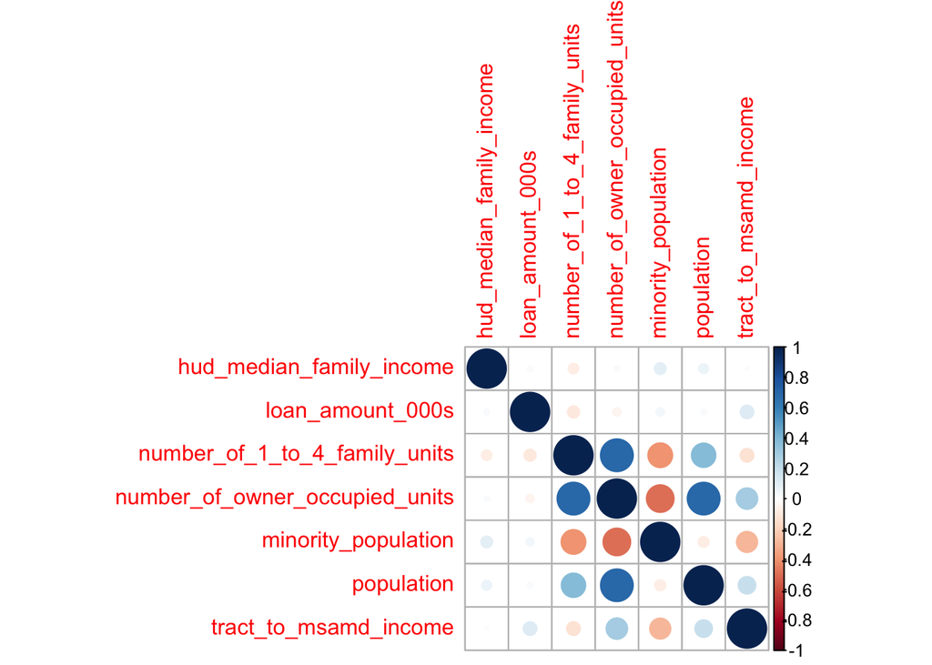

```r
corrplot(correlation_of_variables)
```

The variable number_of_owner_occupied_units exhibits a strong correlation with number_of_1_to_4_family_units and population. This correlation is intuitive, as areas with higher populations tend to have more residences across all categories. To address multicollinearity in our dataset, employing techniques like feature selection or Principal Component Analysis (PCA) is advisable.

For feature selection, the step_cor() function from tidymodels proves convenient. By specifying a threshold with the threshold parameter, we can efficiently eliminate variables with high absolute correlations. It’s crucial to note that this step, like a recipe in cooking, merely outlines the process without executing it automatically. The actual execution involves using the prep() and bake() functions. prep() customizes the preprocessing to our dataset, determining which variables to remove based on the correlation threshold. On the other hand, bake() applies the specified recipe to the dataset, producing a new, preprocessed dataset.

```r
corr_mortgage <- mortgage_rec %>%
  step_corr(all_numeric_predictors(),
            threshold = 0.5,
            id = 'remove variables with large correlation')

tidy(corr_mortgage, number = 1)
```

| terms | value | id |
| --- | --- | --- |
| msamd_name | New York, Jersey City, White Plains - NY, NJ | impute_mode_21vk7 |

Note that this doesn’t actually update the data. Steps in a workflow aren’t excecuted automatically. Recipes in Tidy Modeling are like recipes in real life: they just describe the steps we will perform on our ingredients, but it is not the execution of the cooking itself. Following this culinary analogy, the functions used to apply the recipe to the dataset are `prep()` and `bake()`. `prep()` fits the preprocessing to our defined dataset, it tunes the parameters of the modeling to our variables and features. In this scenario, it computes the correlation of the variables to define which ones will be removed according to the threshold. `bake()` actually applies the recipe to the dataset and returns a new, preproccessed dataset.

```r
baked_corr <- corr_mortgage %>%
  prep() %>%
  bake(new_data = data)

colnames(baked_corr)
```

```
##  [1] "respondent_id"                 "agency_name"
##  [3] "applicant_ethnicity_name"      "applicant_race_name_1"
##  [5] "applicant_sex_name"            "co_applicant_ethnicity_name"
##  [7] "co_applicant_race_name_1"      "co_applicant_sex_name"
##  [9] "county_name"                   "lien_status_name"
## [11] "loan_purpose_name"             "loan_type_name"
## [13] "msamd_name"                    "owner_occupancy_name"
## [15] "preapproval_name"              "property_type_name"
## [17] "purchaser_type_name"           "hud_median_family_income"
## [19] "loan_amount_000s"              "number_of_1_to_4_family_units"
## [21] "minority_population"           "population"
## [23] "tract_to_msamd_income"         "action_taken_name"
```

It’s important to recognize that after feature selection, the dataset contains 24 variables instead of the original 25, reflecting the removal of variables like `number_of_owner_occupied_units.`

Now, how would we do this with PCA? Recall that PCA is an unsupervised modeling method that reduces the dimensionality of a set of features by producing components that are the linear combination of those features. We could input the variables correlated and generate two principal components that explain the variability of our data and reduce multicolinearity.

```r
step_pca_estimates <- mortgage_rec %>%
  step_pca(
    number_of_owner_occupied_units, number_of_1_to_4_family_units, population,
    num_comp = 2,
    options = list(rank. = 2)
  ) %>%
  prep()


tidy(step_pca_estimates, number = 1)
```

| terms | value | id |
| --- | --- | --- |
| msamd_name | New York, Jersey City, White Plains - NY, NJ | impute_mode_21vk7 |

### Transformation of variables

In our class notes, another topic we covered was the transformation of existing variables. This transformation typically involves recoding variables and normalizing them.

For categorical variables, two valuable transformations supported by recipes involve creating dummy variables and grouping observations with minimal occurrences into an ‘Other’ category.

```r
other_rec <- mortgage_rec %>%
  step_other(msamd_name, co_applicant_race_name_1,
             threshold = 0.10,
            id = 'recode other variables') %>%
  prep()

tidy(other_rec, number = 1)
```

| terms | value | id |
| --- | --- | --- |
| msamd_name | New York, Jersey City, White Plains - NY, NJ | impute_mode_21vk7 |

Another method involves recoding variables through the creation of dummy variables. In scenarios where models only accept quantitative inputs, transforming categorical values into numerical ones is essential. This transformation results in new variables, each representing a category from the original column. These variables adopt a binary format, indicating the presence (1) or absence (0) of a specific category. This process enables us to represent categorical information in a numerical format compatible with models that necessitate numerical input.

With `recipes()`, we can achieve this using the function `step_dummy()`. This function aids in creating these binary representations of categorical variables.

```r
dummy_mortgage <- mortgage_rec %>%
  step_dummy(agency_name:purchaser_type_name,
            id = 'create dummy variables')

baked_dummy <- dummy_mortgage %>%
  prep() %>%
  bake(new_data = data)

baked_dummy %>%
  select(starts_with('applicant_race_name'))
```

| applicant_race_name_1_Asian | applicant_race_name_1_Black.or.African.American | applicant_race_name_1_Information.not.provided.by.applicant.in.mail..Internet..or.telephone.application | applicant_race_name_1_Native.Hawaiian.or.Other.Pacific.Islander | applicant_race_name_1_Not.applicable | applicant_race_name_1_White |
| --- | --- | --- | --- | --- | --- |
| 0 | 0 | 0 | 0 | 0 | 1 |
| 0 | 0 | 0 | 0 | 0 | 1 |
| 0 | 0 | 0 | 0 | 0 | 1 |
| 0 | 0 | 0 | 0 | 0 | 1 |
| 0 | 0 | 0 | 0 | 0 | 1 |
| 0 | 0 | 0 | 0 | 0 | 1 |
| 0 | 0 | 0 | 0 | 0 | 1 |
| 0 | 0 | 1 | 0 | 0 | 0 |
| 1 | 0 | 0 | 0 | 0 | 0 |
| 0 | 0 | 0 | 0 | 1 | 0 |

[output cut: 9990 more lines]

Note that this generates 6 new columns, reflecting the encoding of the original variable into this.

For quantitative variables, common kinds of preprocessing are centering, scaling or normalization of variables. These methods are related to adjusting the distribution of variables so they can be comparable and used for machine learning models.

Centering involves shifting the values of a variable so that the mean becomes zero. The goal is to remove any inherent bias or offset in the data. It is done by substracting the average of a variable from all the observations in said variable. It can be done with the function `step_center()`.

```r
center_rec <- mortgage_rec %>%
  step_center(all_numeric_predictors(),
            id = 'center predictors') %>%
  prep()

tidy(center_rec, number = 1)
```

| terms | value | id |
| --- | --- | --- |
| msamd_name | New York, Jersey City, White Plains - NY, NJ | impute_mode_21vk7 |

Scaling a variable implies normalizing the data to have a standard deviation of one. It can be done with `step_scale()`. The function scales numerical variables to a specified range or *standardizes* them to have a mean of zero and a standard deviation of one.

```r
scale_rec <- mortgage_rec %>%
  step_scale(all_numeric_predictors()) %>%
  prep()

tidy(scale_rec, number = 1)
```

| terms | value | id |
| --- | --- | --- |
| msamd_name | New York, Jersey City, White Plains - NY, NJ | impute_mode_21vk7 |

Finally, normalizing scales the values of a variable to a standard scale, usually with a mean of 0 and a standard deviation of 1. It is the operation of scaling and centering a variable, with the goal to bring all variables to a similar scale, facilitating comparisons. It can be done with the function `step_normalize()`.

```r
normalize_rec <- mortgage_rec %>%
  step_normalize(all_numeric_predictors(),
            id = 'normalize predictors') %>%
  prep()

tidy(normalize_rec, number = 1)
```

| terms | value | id |
| --- | --- | --- |
| msamd_name | New York, Jersey City, White Plains - NY, NJ | impute_mode_21vk7 |

In summary, when it comes to handling statistical models in R with a tidy methodology, the go-to framework is `tidymodels`. This approach encapsulates the entire modeling workflow, encompassing preprocessing, modeling, and subsequent post-processing stages. While basic tidyverse functions like `mutate`, `filter`, `drop_na`, and plotting tools can execute some preprocessing tasks, leveraging recipes within `tidymodels` [offers a wide range of `step_` functions explicitly created for data preparation in modeling contexts.](https://recipes.tidymodels.org/reference/index.html) These specialized functions enhance data preprocessing, ensuring it aligns effectively with the goal of building robust models. The is the comprehensive workflow that `tidymodels` enables, seamlessly integrating various stages to create effective and reliable statistical models.

“Manually Alter Roles Roles.” n.d. https://recipes.tidymodels.org/reference/roles.html.

Silge, Max Kuhn, and Julia. n.d. *A Recommended Preprocessing | Tidy Modeling with r*. https://www.tmwr.org/pre-proc-table.html#tab:preprocessing.